# DoSomething Data Analyst Intern Assignment

Michelle Chung

March 16, 2018

This document explores the DoSomething dataset “member_event_log_20180305.csv”. It is intended to provide a brief summary and present initial findings of the data based the DoSomething Data Analyst intern assignment guidelines.

I make the following assumptions about the product in my analysis:

- In the life cycle of the user, account creation occur only once per unique user.
- A sign-up indicates that a user has signed up to participate in a task or an event.
- A reportback indicates that a user has marked that they have completed a task or event.

### Summary

```r
data_summary
```

```
                             event_id                           user_id
 000002d84f76050cff3b16b958085b97:      1   59825778a0bfad7f2a09e6ff:  37823
 00000afc4a7b604b3acf88ed2e9f6ffd:      1   563a332d469c64d6708b48d1:  16436
 00000b161540d28f1fdf85ec4a4dbea9:      1   5a3acd23a0bfad43ec4542e6:   8152
 00000d042463719fa3a7ff877c783584:      1   5a1c42d8a0bfad2099780a37:   2203
 00000d81093b3788b84f62e7232bca26:      1   57e9301242a06450498b456b:   1289
 00000e7a2e53c0cc4043a924384d0d81:      1   55a8516c469c646a348cfc0a:   1278
 (Other)                         :3533858   (Other)                 :3466683
           action_type      channel                      timestamp
 account_creation: 620803   paid:1238059   2018-01-03 21:03:51:     34
 reportback      : 118174   sms : 801768   2018-01-03 21:03:50:     27
 sign-up         :1935841   web :1494037   2017-10-23 15:34:33:     25
 site_access     : 532776                  2017-10-23 15:41:38:     25
 site_login      : 326270                  2017-10-23 15:41:59:     25
                                           2017-10-23 15:42:35:     25
                                           (Other)            :3533703
```

The data_summary tells us that this dataset records a unique event identified by an `event_id`. The `user_id`, `action_type`, `channel`, and `timestamp` are recorded for each event.

### Analysis

#### There is a clear discrepancy in the amount of sign-ups and the amount of report-backs.

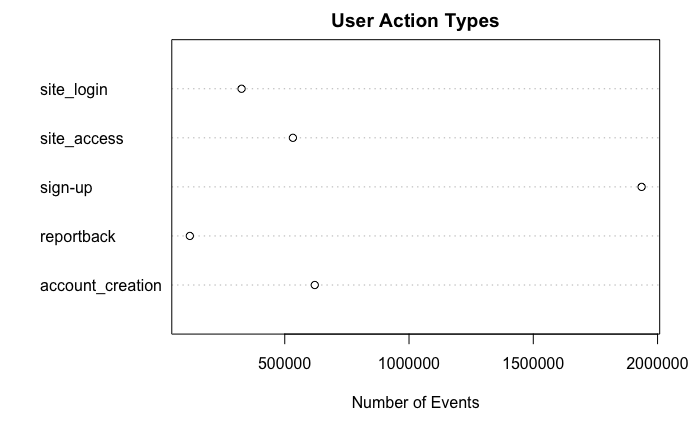

It appears that sign-ups are the most common user actions–and that’s great! But reportbacks give us a better understanding of how many users are actually participating in these events. Perhaps we could add or alter a feature that makes reportbacks easier to complete.

### Notes

Given more time, I would have liked to explore the following:

- The distribution of events over time. This was the big one that I really wanted to do, but wasn’t able to get to complete cohesively under the four-hour time limit. My initial approach was to go from really large (month-by-month) to really granular (minute-by-minute). The time data was, in my opinion, the juiciest feature–perhaps I should have tackled it first. I think predictive models based on the time data would have helped support strong product recommendations.
- To add to the above point: Distribution of the different action types over time. At what times are people most likely to perform certain actions?
- Sort the data by least to most active users (based on number of actions). Who are the power users? What metric can we produce, other than collecting events, that can tell us about user engagement?
- How can we use the data to understand what makes someone likely to report back? Are there other events that correlate with a reportback?

In regards to enriching the data, I would have loved to see more information about the users as well as the events they signed up for. For users, features like age, occupation, and location would have been interesting to explore; for events, time/date data, location, event organizers, and information about event attendees are just a few things I can think of that would have yielded more interesting results.